# maftools : Summarize, Analyze and Visualize MAF files

Anand Mayakonda

2016-07-08

# 1 Introduction.

With advances in Cancer Genomics, Mutation Annotation Format (MAF) is being widley accepted and used to store somatic variants detected. [The Cancer Genome Atlas](http://cancergenome.nih.gov) Project has seqenced over 30 different cancers with sample size of each cancer type being over 200. [Resulting data](https://wiki.nci.nih.gov/display/TCGA/TCGA+MAF+Files) consisting of somatic variants are stored in the form of Mutation Annotation Format. This package attempts to summarize, analyze, annotate and visualize MAF files in an efficient manner from either TCGA sources or any in-house studies as long as the data is in MAF format.

# 2 MAF field requirements.

MAF files contain many fields ranging from chromosome names to cosmic annotations. However most of the analysis in maftools uses following fields.

- Mandatoty fields: **Hugo_Symbol, Chromosome, Start_Position, End_Position, Variant_Classification, Variant_Type and Tumor_Sample_Barcode**.
- Recommended optional fields: non MAF specific fields containing vaf and amino acid change information.

Complete specififcation of MAF files can be found on NCI TCGA page.

This vignette demonstrates the usage and application of maftools on an example MAF file from TCGA LAML cohort 1.

# 3 Reading and summarizing maf files.

## 3.1 Reading MAF files.

`read.maf` reads MAF files, summarizes it in various ways and stores it as an MAF object.

```r
suppressPackageStartupMessages(require(maftools))
#read TCGA maf file for LAML
laml.maf = system.file('extdata', 'tcga_laml.maf.gz', package = 'maftools')
laml = read.maf(maf = laml.maf, removeSilent = TRUE, useAll = FALSE)
```

## 3.2 MAF object

Summarized MAF file is stored as an MAF object. MAF object contains main maf file, summarized data and an oncomatrix which is useful to plot oncoplots (aka waterfall plots). There are accessor methods to access the useful slots from MAF object. However, all slots can be accessed using `@`, just like most of S4 objects.

```r
#Typing laml shows basic summary of MAF file.
laml
```

```
## An object of class  MAF
##                    ID          summary       Mean Median
##  1:        NCBI_Build               37         NA     NA
##  2:            Center genome.wustl.edu         NA     NA
##  3:           Samples              192         NA     NA
##  4:            nGenes             1241         NA     NA
##  5:   Frame_Shift_Del               52 0.27083333      0
##  6:   Frame_Shift_Ins               91 0.47395833      0
##  7:      In_Frame_Del               10 0.05208333      0
##  8:      In_Frame_Ins               42 0.21875000      0
##  9: Missense_Mutation             1342 6.98958333      7
## 10: Nonsense_Mutation              103 0.53645833      0
## 11:       Splice_Site               92 0.47916667      0
## 12:             total             1732 9.02083333      9
```

```r
#Shows sample summry.
getSampleSummary(laml)
```

```
##      Tumor_Sample_Barcode Frame_Shift_Del Frame_Shift_Ins In_Frame_Del
##   1:         TCGA.AB.3009               0               5            0
##   2:         TCGA.AB.2807               1               0            1
##   3:         TCGA.AB.2959               0               0            0
##   4:         TCGA.AB.3002               0               0            0
##   5:         TCGA.AB.2849               0               1            0
##  ---
## 188:         TCGA.AB.2933               0               0            0
## 189:         TCGA.AB.2942               0               0            0
## 190:         TCGA.AB.2946               0               0            0
## 191:         TCGA.AB.2954               0               0            0
## 192:         TCGA.AB.2982               0               0            0
##      In_Frame_Ins Missense_Mutation Nonsense_Mutation Splice_Site total
##   1:            1                25                 2           1    34
##   2:            0                16                 3           4    25
##   3:            0                22                 0           1    23
##   4:            0                15                 1           5    21
##   5:            0                16                 1           2    20
##  ---
## 188:            0                 1                 0           0     1
## 189:            1                 0                 0           0     1
## 190:            0                 1                 0           0     1
## 191:            0                 1                 0           0     1
## 192:            0                 1                 0           0     1
```

```r
#Shows frequently mutated genes.
getGeneSummary(laml)
```

```
##       Hugo_Symbol Frame_Shift_Del Frame_Shift_Ins In_Frame_Del
##    1:        FLT3               0               0            1
##    2:      DNMT3A               4               0            0
##    3:        NPM1               0              33            0
##    4:        IDH2               0               0            0
##    5:        IDH1               0               0            0
##   ---
## 1237:      ZNF689               0               0            0
## 1238:      ZNF75D               0               0            0
## 1239:      ZNF827               1               0            0
## 1240:       ZNF99               0               0            0
## 1241:        ZPBP               0               0            0
##       In_Frame_Ins Missense_Mutation Nonsense_Mutation Splice_Site total
##    1:           33                15                 0           3    52
##    2:            0                39                 5           6    54
```

[output cut: 21 more lines]

```r
#Shows all fields in MAF
getFields(laml)
```

```
##  [1] "Hugo_Symbol"            "Entrez_Gene_Id"
##  [3] "Center"                 "NCBI_Build"
##  [5] "Chromosome"             "Start_Position"
##  [7] "End_Position"           "Strand"
##  [9] "Variant_Classification" "Variant_Type"
## [11] "Reference_Allele"       "Tumor_Seq_Allele1"
## [13] "Tumor_Seq_Allele2"      "Tumor_Sample_Barcode"
## [15] "Protein_Change"         "i_TumorVAF_WU"
## [17] "i_transcript_name"
```

```r
#Writes maf summary to an output file with basename laml.
write.mafSummary(maf = laml, basename = 'laml')
```

# 4 Visualization.

## 4.1 Plotting MAF summary.

We can use `plotmafSummary` to plot the summary of the maf file, which displays number of variants in each sample as a stacked barplot and variant types as a boxplot summarized by Variant_Classification. We can add either mean or median line to the stacked barplot to display average/median number of variants across the cohort.

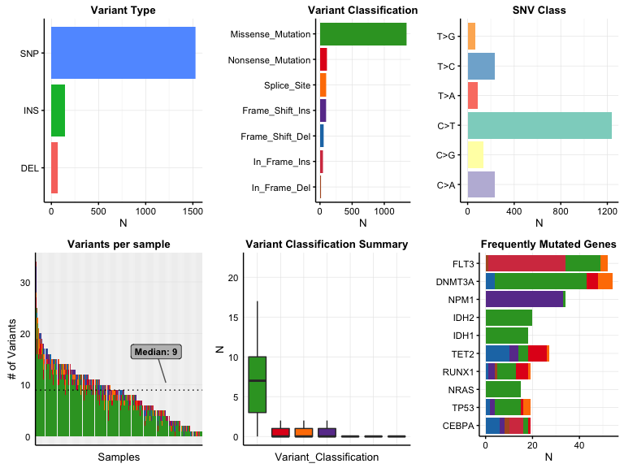

```r
plotmafSummary(maf = laml, rmOutlier = TRUE, addStat = 'median', dashboard = TRUE)
```

## 4.2 Oncoplots (aka waterfall plots)

### 4.2.1 Drawing oncoplots.

Bettter representaion of maf file can be shown as oncoplots, also known as waterfall plots. Oncoplot function uses ComplexHeatmap to draw oncoplots. Side barplot and top barplots can be controlled by `drawRowBar` and `drawColBar` arguments respectivelly.

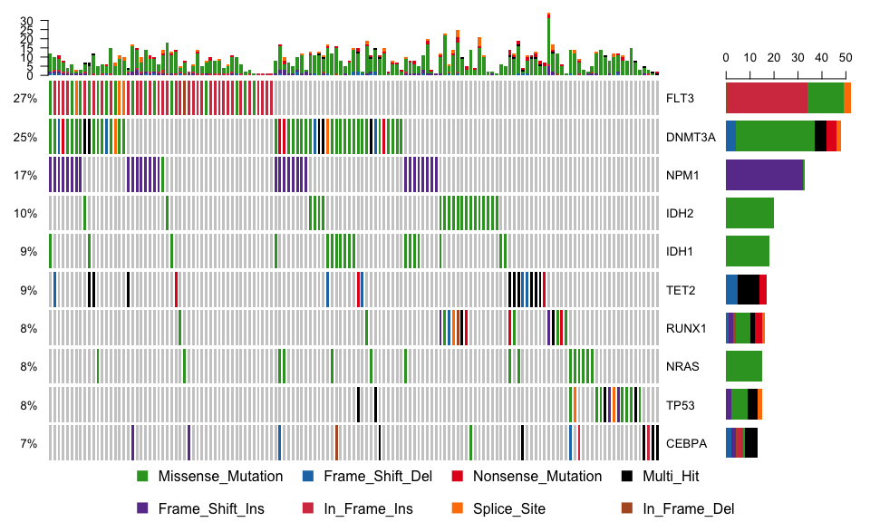

```r
#We will draw oncoplots for top ten mutated genes. (Removing non-mutated samples from the plot for better visualization)
oncoplot(maf = laml, top = 10, removeNonMutated = TRUE)
```

NOTE: Variants annotated as `Multi_Hit` are those genes which are mutated more than once in the same sample.

### 4.2.2 Including copy number data into oncoplots.

If we have copy number data along with MAF file, we can include them in oncoplot as to show if any genes are amplified or deleted. One most widely used tool for copy number analysis from large scale studies is GISTIC and we can simultaneously read gistic results along with MAF. GISTIC generates numerous files but we need mainly three files `all_lesions.conf_XX.txt`, `amp_genes.conf_XX.txt` and `del_genes.conf_XX.txt`, where XX is confidence level. These files contain significantly altered genomic regions along with amplified and delted genes respectively.

```r
suppressWarnings(require(maftools))
#read TCGA maf file for LAML
laml.maf = system.file('extdata', 'tcga_laml.maf.gz', package = 'maftools')
all.lesions <- system.file("extdata", "all_lesions.conf_99.txt", package = "maftools")
amp.genes <- system.file("extdata", "amp_genes.conf_99.txt", package = "maftools")
del.genes <- system.file("extdata", "del_genes.conf_99.txt", package = "maftools")
laml.plus.gistic = read.maf(maf = laml.maf, removeSilent = TRUE, useAll = FALSE, gisticAllLesionsFile = all.lesions, gisticAmpGenesFile = amp.genes, gisticDelGenesFile = del.genes, isTCGA = TRUE)
```

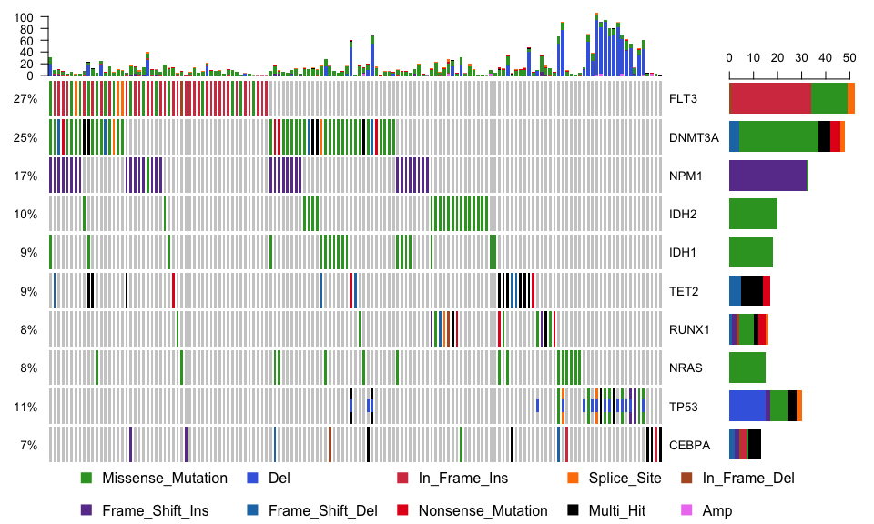

```r
#We will draw oncoplots for top ten mutated genes. (Removing non-mutated samples from the plot for better visualization)
oncoplot(maf = laml.plus.gistic, top = 10, removeNonMutated = TRUE, sortByMutation = TRUE)
```

This plot shows frequent deletions in TP53 gene which is located on one of the significanlty deleted locus 17p13.2.

### 4.2.3 Changing colors and adding annotations to oncoplots.

It is often the case that we include meta data to show sample characterstics such as gender, treatment, etc. We can include such meta data by passing them to `annotation` argument of `oncoplot`. We can also change colors for Variant_Classification by providing a named vector of colors.

```r
#Read FAB classification of TCGA LAML barcodes.
laml.fab.anno = system.file('extdata', 'tcga_laml_fab_annotation.txt', package = 'maftools')
laml.fab.anno = read.delim(laml.fab.anno, sep = '\t')
head(laml.fab.anno)
```

```
##   Tumor_Sample_Barcode FAB_classification
## 1         TCGA-AB-2802                 M4
## 2         TCGA-AB-2803                 M3
## 3         TCGA-AB-2804                 M3
## 4         TCGA-AB-2805                 M0
## 5         TCGA-AB-2806                 M1
## 6         TCGA-AB-2807                 M1
```

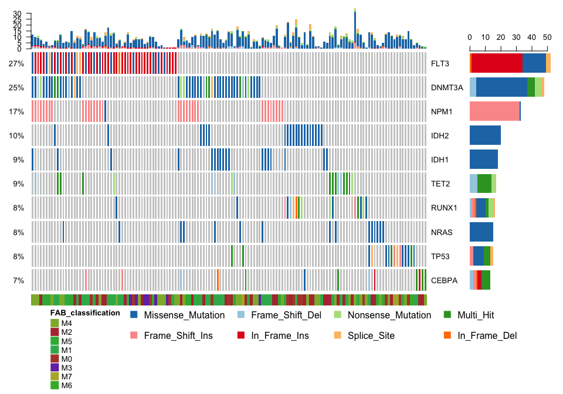

```r
#Changing colors (You can use any colors, here in this example we will use a color palette from RColorBrewer)
col = RColorBrewer::brewer.pal(n = 8, name = 'Paired')
names(col) = c('Frame_Shift_Del','Missense_Mutation', 'Nonsense_Mutation', 'Multi_Hit', 'Frame_Shift_Ins',
               'In_Frame_Ins', 'Splice_Site', 'In_Frame_Del')
#We will plot same top ten mutated genes with FAB classification as annotation and using above defined colors.
oncoplot(maf = laml, top = 10, annotation = laml.fab.anno, removeNonMutated = TRUE, colors = col)
```

## 4.3 Oncostrip

We can visualize any set of genes using `oncostrip` function, which draws mutations in each sample similar to [OncoPrinter tool](http://www.cbioportal.org/faq.jsp#what-are-oncoprints) on [cBioPortal](http://www.cbioportal.org/index.do). `oncostrip` can be used to draw any number of genes using `top` or `genes` arguments.

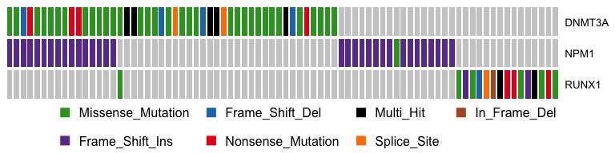

```r
oncostrip(maf = laml, genes = c('DNMT3A','NPM1', 'RUNX1'), removeNonMutated = TRUE, showTumorSampleBarcodes = FALSE)
```

## 4.4 Transition and Transversions.

`titv` function classifies SNPs into [Transitions and Transversions](http://www.mun.ca/biology/scarr/Transitions_vs_Transversions.html) and returns a list of summarized tables in various ways. Summarized data can also be visulaized as a boxplot showing overall distribution of six different conversions and as a stacked barplot showing fraction of conversions in each sample.

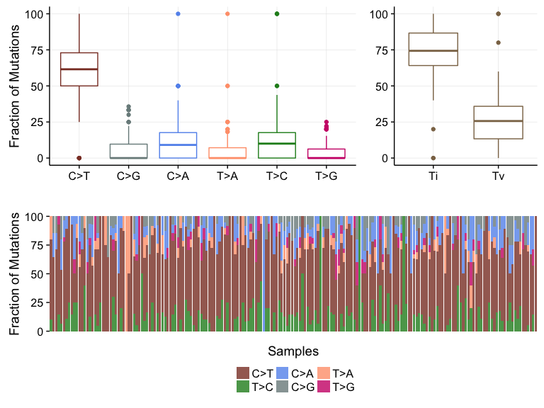

```r
laml.titv = titv(maf = laml, plot = FALSE, useSyn = TRUE)
#plot titv summary
plotTiTv(res = laml.titv)
```

## 4.5 Lollipop plots for amino acid changes.

Lollipop plots are simple and most effective way showing mutation spots on protein structure. Many oncogenes have a preferential sites which are mutated more often than any other locus. These spots are considered to be mutational hotspots and lollipop plots can be used to display them along with rest of the mutations. We can draw such plots using the function `lollipopPlot`. This fuction requires us to have amino acid changes information in the maf file. However MAF files have no clear guidelines on naming the field for amino acid changes, with different studies having different field (or column) names for amino acid changes. By default, `lollipopPlot` looks for column `AAChange`, and if its not found in the MAF file, it prints all availble fields with a warning message. For below example, MAF file contains amino acid changes under a field/column name ‘Protein_Change’. We will manually specify this using argumnet `AACol`. This function also returns the plot as a ggplot object, which user can later modify if needed.

```
## 3 transcripts available. Use arguments refSeqID or proteinID to manually specify tx name.
```

```
##       HGNC refseq.ID protein.ID aa.length Start End          Label
##  1: DNMT3A NM_175629  NP_783328       912   290 376 Dnmt3b_related
##  2: DNMT3A NM_175629  NP_783328       912   478 614    ADDz_Dnmt3a
##  3: DNMT3A NM_175629  NP_783328       912   632 795            Dcm
##  4: DNMT3A NM_175629  NP_783328       912   634 907  AdoMet_MTases
##  5: DNMT3A NM_022552  NP_072046       912   290 376 Dnmt3b_related
##  6: DNMT3A NM_022552  NP_072046       912   478 614    ADDz_Dnmt3a
##  7: DNMT3A NM_022552  NP_072046       912   632 795            Dcm
##  8: DNMT3A NM_022552  NP_072046       912   634 907  AdoMet_MTases
##  9: DNMT3A NM_153759  NP_715640       723   101 187 Dnmt3b_related
## 10: DNMT3A NM_153759  NP_715640       723   289 425    ADDz_Dnmt3a
## 11: DNMT3A NM_153759  NP_715640       723   443 606            Dcm
## 12: DNMT3A NM_153759  NP_715640       723   445 718  AdoMet_MTases
```

```
## Using longer transcript NM_175629 for now.
```

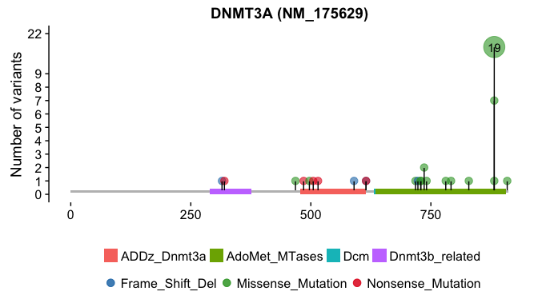

```r
#Lets plot lollipop plot for DNMT3A, which is one of the most frequent mutated gene in Leukemia.
dnmt3a.lpop = lollipopPlot(maf = laml, gene = 'DNMT3A', AACol = 'Protein_Change')
```

Note that `lollipopPlot` warns user on availability of diferent transcripts for the given gene. If we know the transcript id before hand, we can specify it as `refSeqID` or `proteinID`. By default lollipopPlot uses the longer isoform.

### 4.5.1 Labelling and repelling points.

We can also label points on the `lollipopPlot` using argument `labelPos`. If `labelPos` is set to ‘all’, all of the points are highlighted. Sometimes, many mutations are clustered within a range of few amino acid positons. In that case we can use `repel` option which tries to repel points for clear representation.

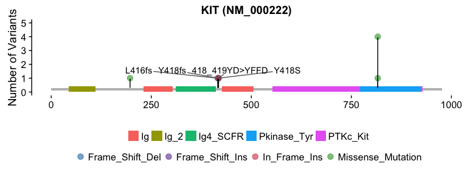

```r
#Lets plot mutations on KIT gene, without repel option.
kit.lpop = lollipopPlot(maf = laml, gene = 'KIT', AACol = 'Protein_Change', labelPos = c(416, 418), refSeqID = 'NM_000222')
```

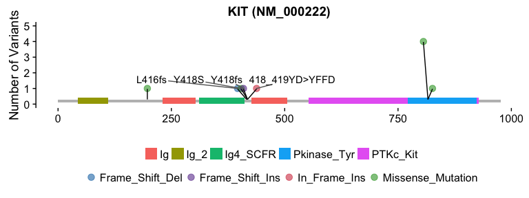

```r
#Same plot with repel=TRUE
kit.lpop = lollipopPlot(maf = laml, gene = 'KIT', AACol = 'Protein_Change', labelPos = c(416, 418), refSeqID = 'NM_000222', repel = TRUE)
```

## 4.6 Integrating somatic variants and copy number alterations

Many cancer genomic studies involve copy number data generated either from sequencing or SNP chip arrays. Copy number analysis provides us a lot of information from genome wide copy number aberations to tumor purity. Most of the time copy number data is stored as segments, with each segment represented by a log ratio of copy number changes compared to matched normals. There are many segmentation algorithms, with the most popular being Circular Binary Segmentation implemented in [DNACopy bioconductor](https://www.bioconductor.org/packages/3.3/bioc/html/DNAcopy.html). We can plot such segmented copy number data and map all mutations on to it. It provides a quick way of knowing which variants (in a way which genes) are located on copy number altered genomic regions.

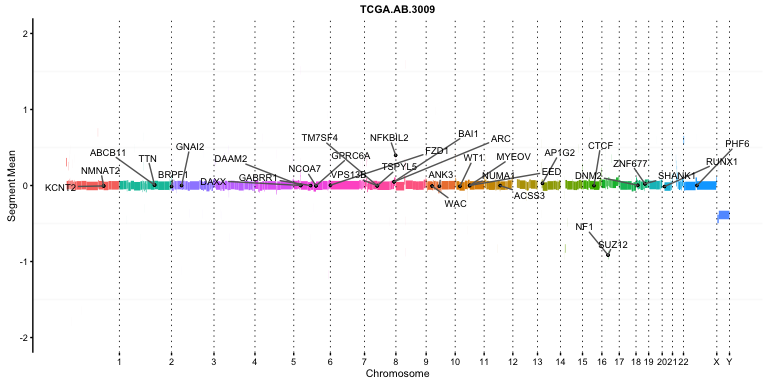

```r
tcga.ab.009.seg <- system.file("extdata", "TCGA.AB.3009.hg19.seg.txt", package = "maftools")
plotCBSsegments(cbsFile = tcga.ab.009.seg, maf = laml, labelAll = TRUE)
```

Above plot shows two genes NF1 and SUZ12 are located on a region which has a shallow deletion. Later we will also see how these variants on copy number altered regions affect variant allele frequencies and tumor heterogeneity estimation.

## 4.7 Rainfall plots

Cancer genomes, especially solid tumors are characterized by genomic loci with localized hypermutations9. Such hyper mutated genomic regions can be visualized by plotting inter variant distance on a linear genomic scale. These plots generally called rainfall plots and we can draw such plots using `rainfallPlot`.

```r
coad <- system.file("extdata", "coad.maf.gz", package = "maftools")
coad = read.maf(maf = coad)
```

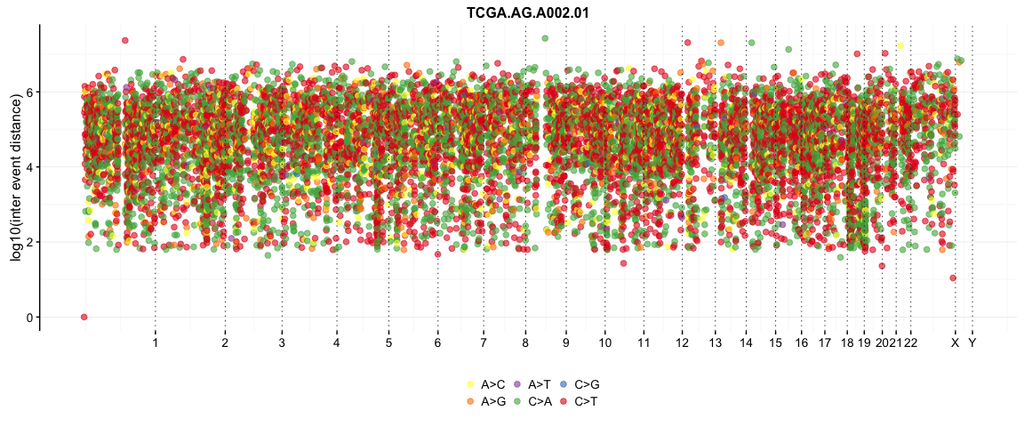

```r
coad.rf = rainfallPlot(maf = coad)
```

## 4.8 Genecloud

We can plot word cloud plot for mutated genes with the function `geneCloud`. Size of each gene is proportional to the total number of samples in which it is mutated/altered.

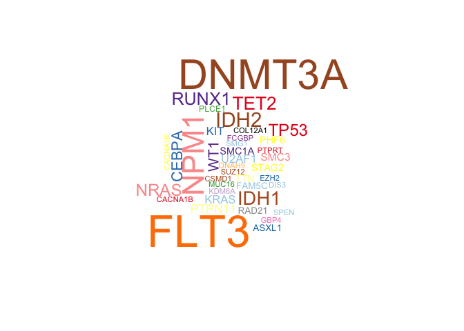

```r
geneCloud(input = laml, minMut = 3)
```

# 5 GISTIC files.

## 5.1 Reading and summarizing gistic output files.

We can summarize output files generated by GISTIC programme. As mentioned earlier, we need three files that were generated by GISTIC, i.e, all_lesions.conf_XX.txt, amp_genes.conf_XX.txt and del_genes.conf_XX.txt, where XX is the confidence level. See GISTIC documentation for details.

```r
all.lesions <- system.file("extdata", "all_lesions.conf_99.txt", package = "maftools")
amp.genes <- system.file("extdata", "amp_genes.conf_99.txt", package = "maftools")
del.genes <- system.file("extdata", "del_genes.conf_99.txt", package = "maftools")
laml.gistic = readGistic(gisticAllLesionsFile = all.lesions, gisticAmpGenesFile = amp.genes, gisticDelGenesFile = del.genes, isTCGA = TRUE)
```

```
## Processing Gistic files..
```

Similar to MAF objects, there are methods available to access slots of GISTIC object - `getSampleSummary`, `getGeneSummary` and `getCytoBandSummary`. Summarized results can be written to output files using function `write.GisticSummary`.

## 5.2 Visualizing gistic results.

### 5.2.1 Gistic plots.

Similar to oncoplots we can draw copy number data.

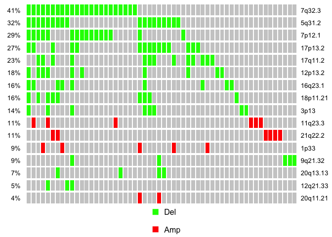

```r
gisticPlot(gistic = laml.gistic)
```

### 5.2.2 Plot gistic results.

A bubble plot to display summarized gistic results.

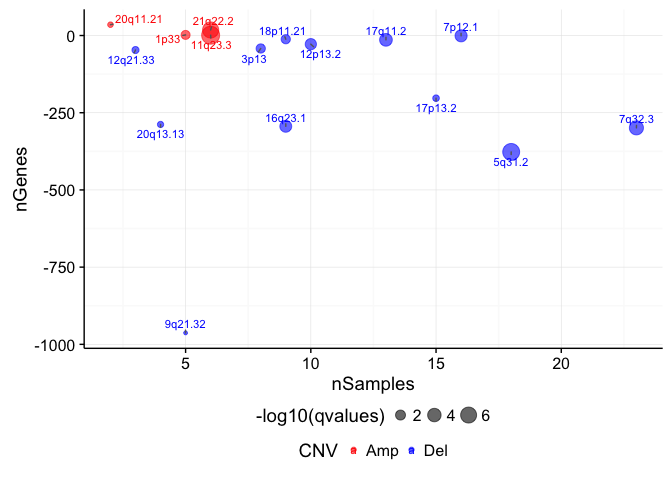

```r
plotGisticResults(gistic = laml.gistic)
```

# 6 Analysis.

## 6.1 Mutual exclusivity.

Many disease causing genes in cancer show strong exlcusiveness in their mutation pattern. Such mutually exlcuive set of genes can be detected using `mutExclusive` function, which performs an exact test to detect such significant pair of genes. `mutExclusive` uses `comet_exact_test` on a given set of genes to calculate significance value. Please cite [CoMET](http://www.ncbi.nlm.nih.gov/pmc/articles/PMC4531541/) article if you use this function 2.

```r
#We will run mutExclusive on top 10 mutated genes.
laml.mut.excl = mutExclusive(maf = laml, top = 10)
head(laml.mut.excl)
```

```
##   n.00 n.01 n.10 n.11  gene1 gene2                pval
## 1  125   15   52    0   FLT3  TP53 0.00352781328800287
## 2  139   20   33    0   NPM1  IDH2  0.0092131137152039
## 3  143   16   33    0   NPM1 RUNX1  0.0213098782919558
## 4  125   15   51    1   FLT3 RUNX1   0.021565502698412
## 5  144   15   33    0   NPM1  TP53  0.0261933920671912
## 6  129   15   47    1 DNMT3A RUNX1  0.0319088921944485
```

We can visualize the above results using `oncostrip`. For example in above `mutExclusive` analysis, we can see many genes show exclusiveness. For example NPM1 and RUNX1 show a strong exclusiveness with a p-value of 0.02.

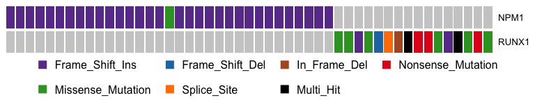

```r
oncostrip(maf = laml, genes = c('NPM1', 'RUNX1'), sort = TRUE, removeNonMutated = TRUE)
```

## 6.2 Detecting cancer driver genes based on positional clustering.

maftools has a function `oncodrive` which identifies cancer genes (driver) from a given MAF. `oncodrive` is a based on algorithm [oncodriveCLUST](http://bg.upf.edu/group/projects/oncodrive-clust.php) which was originally implemented in Python. Concept is based on the fact that most of the variants in cancer causing genes are enriched at few specific loci (aka hotspots). This method takes advantage of such positions to identify cancer genes. If you use this function, please cite [OncodriveCLUST article](http://bioinformatics.oxfordjournals.org/content/early/2013/07/31/bioinformatics.btt395.full) 3.

```r
laml.sig = oncodrive(maf = laml, AACol = 'Protein_Change', minMut = 5, pvalMethod = 'zscore')
head(laml.sig)
```

[output not shown]

We can plot the results using `plotOncodrive`.

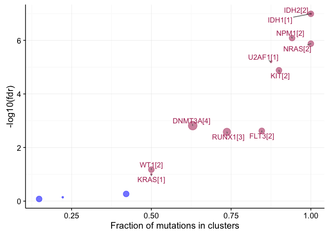

```r
plotOncodrive(res = laml.sig, fdrCutOff = 0.1, useFraction = TRUE)
```

`plotOncodrive` plots the results as scatter plot with size of the points proportional to the number of clusters found in the gene. X-axis shows number of mutations (or fraction of mutations) observed in these clusters. In the above example, IDH1 has a single cluster and all of the 18 mutations are accumulated within that cluster, giving it a cluster score of one. For details on oncodrive algorithm, please refer to [OncodriveCLUST article](http://bioinformatics.oxfordjournals.org/content/early/2013/07/31/bioinformatics.btt395.full) 3.

## 6.3 Adding and summarizing pfam domains.

maftools comes with the function `pfamDomains`, which adds pfam domain information to the amino acid changes. `pfamDomain` also summarizes amino acid changes accoriding to the domains that are affected. This serves the puposes of knowing what domain in given cancer cohort, is most frequently affected. This function is inspired from Pfam annotation modulce from MuSic tool 4.

```r
laml.pfam = pfamDomains(maf = laml, AACol = 'Protein_Change', top = 10)
```

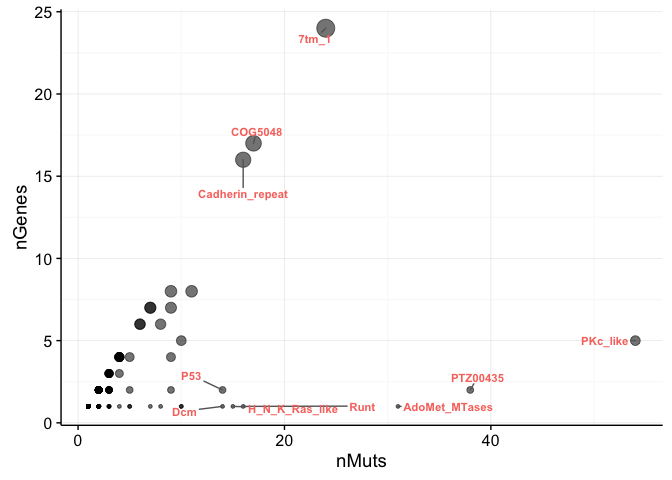

```r
#Protein summary (Printing first 7 columns for display convenience)
laml.pfam$proteinSummary[,1:7, with = FALSE]
```

```
##         HGNC AAPos Variant_Classification  N total  fraction   DomainLabel
##    1: DNMT3A   882      Missense_Mutation 27    54 0.5000000 AdoMet_MTases
##    2:   IDH1   132      Missense_Mutation 18    18 1.0000000      PTZ00435
##    3:   IDH2   140      Missense_Mutation 17    20 0.8500000      PTZ00435
##    4:   FLT3   835      Missense_Mutation 14    52 0.2692308      PKc_like
##    5:   FLT3   599           In_Frame_Ins 10    52 0.1923077      PKc_like
##   ---
## 1470: ZNF646   875      Missense_Mutation  1     1 1.0000000            NA
## 1471: ZNF687   554      Missense_Mutation  1     2 0.5000000            NA
## 1472: ZNF687   363      Missense_Mutation  1     2 0.5000000            NA
## 1473: ZNF75D     5      Missense_Mutation  1     1 1.0000000            NA
## 1474: ZNF827   427        Frame_Shift_Del  1     1 1.0000000            NA
```

```r
#Domain summary (Printing first 3 columns for display convenience)
laml.pfam$domainSummary[,1:3, with = FALSE]
```

```
##        DomainLabel nMuts nGenes
##   1:      PKc_like    54      5
##   2:      PTZ00435    38      2
##   3: AdoMet_MTases    31      1
##   4:         7tm_1    24     24
##   5:       COG5048    17     17
##  ---
## 473:    ribokinase     1      1
## 474:   rim_protein     1      1
## 475: sigpep_I_bact     1      1
## 476:           trp     1      1
## 477:        zf-BED     1      1
```

Above plot and results shows AdoMet_MTases domain is frequently mutated, but number genes with this domain is just one (DNMT3A) compared to other domains such as 7tm_1 domain, which is mutated across 24 different genes. This shows the importance of mutations in methyl transfer domains in Leukemia.

## 6.4 Comparing two cohorts (MAFs)

Cancers differ from each other in terms of their mutation pattern. We can compare two different cohorts to detect such differentally mutated genes. For example, recent article by [Madan et. al](http://www.ncbi.nlm.nih.gov/pubmed/27063598) 5, have shown that patients with relapsed APL (Acute Promyelocytic Leukemia) tends to have mutations in PML and RARA genes, which were absent during primary stage of the disease. This difference between two cohorts (in this case primary and relapse APL) can be detected using function `mafComapre`, which performs fisher test on all genes between two cohorts to detect differentally mutated genes.

```r
#Primary APL MAF
primary.apl = system.file("extdata", "APL_primary.maf.gz", package = "maftools")
primary.apl = read.maf(maf = primary.apl)
#Relapse APL MAF
relapse.apl = system.file("extdata", "APL_relapse.maf.gz", package = "maftools")
relapse.apl = read.maf(maf = relapse.apl)
```

```r
#We will consider only genes which are mutated in at-least in 5 samples in one of the cohort, to avoid bias due to single mutated genes.
pt.vs.rt <- mafCompare(m1 = primary.apl, m2 = relapse.apl, m1Name = 'PrimaryAPL', m2Name = 'RelapseAPL', minMut = 5)
print(pt.vs.rt)
```

```
## $results
##     Hugo_Symbol PrimaryAPL RelapseAPL         pval         or       ci.up
##  1:         PML          1         11 1.529935e-05 0.03537381 0.000806034
##  2:        RARA          0          7 2.574810e-04 0.00000000 0.000000000
##  3:       RUNX1          1          5 1.310500e-02 0.08740567 0.001813280
##  4:        FLT3         26          4 1.812779e-02 3.56086275 1.149009169
##  5:      ARID1B          5          8 2.758396e-02 0.26480490 0.064804160
##  6:         WT1         20         14 2.229087e-01 0.60619329 0.263440988
##  7:        KRAS          6          1 4.334067e-01 2.88486293 0.337679367
##  8:        NRAS         15          4 4.353567e-01 1.85209500 0.553883512
##  9:    FLT3_ITD         45         19 7.395415e-01 1.16822368 0.578323868
## 10:      ARID1A          7          4 7.457274e-01 0.80869223 0.195710173
##          ci.low
##  1:   0.2552937
##  2:   0.3006159
##  3:   0.8076265
##  4:  14.7701728
##  5:   0.9698686
##  6:   1.4223101
##  7: 135.5393108
##  8:   8.0373994
##  9:   2.4084408
## 10:   3.9297309
##
## $SampleSummary
##        Cohort SampleSize
## 1: PrimaryAPL        124
## 2: RelapseAPL         58
```

Above resutls show two genes PML and RARA which are highly mutated in Relapse APL compared to Primary APL. We can visulaize these results as a [forestplot](https://en.wikipedia.org/wiki/Forest_plot).

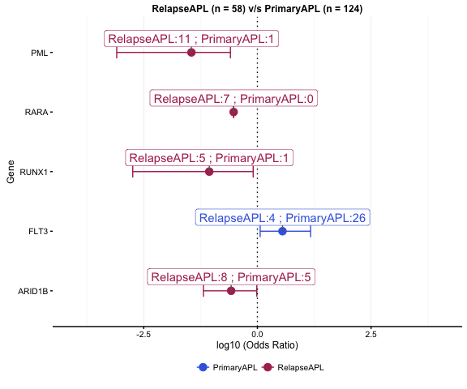

```r
apl.pt.vs.rt.fp = forestPlot(mafCompareRes = pt.vs.rt, pVal = 0.05, show = 'stat', color = c('royalblue', 'maroon'))
```

Another alternative way of displaying above rsults is by plotiing two oncoplots side by side. `coOncoplot` function takes two maf objects and plots them side by side for better comparision.

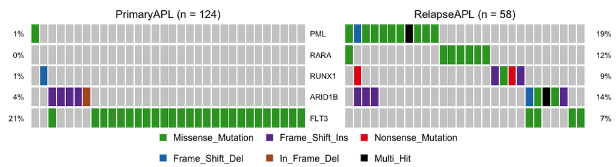

```r
genes = c("PML", "RARA", "RUNX1", "ARID1B", "FLT3")
coOncoplot(m1 = primary.apl, m2 = relapse.apl, m1Name = 'PrimaryAPL', m2Name = 'RelapseAPL', genes = genes, removeNonMutated = TRUE)
```

## 6.5 Tumor heterogeneity and MATH scores.

### 6.5.1 Heterogeneity in tumor samples.

Tumors are generally heterogenous i.e, consist of multiple clones. This heterogenity can be inferred by clustering variant allele frequencies. `inferHeterogeneity` function uses vaf information to cluster variants (using `mclust`), to infer clonality. By default, `inferHeterogeneity` function looks for column *t_vaf* containing vaf information. However, if the field name is different from *t_vaf*, we can manually specify it using argument `vafCol`. For example, in this case study vaf is stored under the field name *i_TumorVAF_WU*.

```r
#We will run this for sample TCGA.AB.2972
tcga.ab.2972.het = inferHeterogeneity(maf = laml, tsb = 'TCGA.AB.2972', vafCol = 'i_TumorVAF_WU')
```

```
## Processing TCGA.AB.2972..
```

```r
print(tcga.ab.2972.het$clusterMeans)
```

```
##    Tumor_Sample_Barcode cluster   meanVaf
## 1:         TCGA.AB.2972       2 0.4496571
## 2:         TCGA.AB.2972       1 0.2454750
## 3:         TCGA.AB.2972 outlier 0.3695000
```

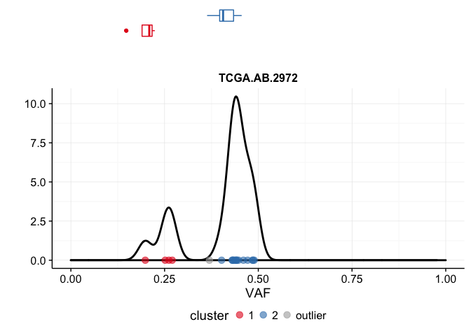

```r
#Visualizing results
plotClusters(clusters = tcga.ab.2972.het)
```

Above figure shows clear seperation of two clones clustered at mean variant allele frequencies of ~45% (major clone) and another minor clone at variant allele frequency of ~25%.

#### 6.5.1.1 Ignoring variants in copy number altered regions.

We can use copy number information to ignore variants located on copynumber altered regions. Copy number alterations results in abnormally high/low variant allele frequencies, which tends to affect clustering. Removing such variants improves clustering and density estimation while retaining biologically meaningful results. Copy number information can be provided as a segmented file generated from segmentation programmes, such as Circular Binary Segmentation from DNACopy Bioconductor package 6.

```r
seg = system.file('extdata', 'TCGA.AB.3009.hg19.seg.txt', package = 'maftools')
tcga.ab.3009.het = inferHeterogeneity(maf = laml, tsb = 'TCGA.AB.3009', segFile = seg)
```

```
## Copy number data found for samples:
```

```
## [1] "TCGA.AB.3009"
```

```
## Processing TCGA.AB.3009..
```

```
## Removed 1 variants with no copy number data.
```

```
##    Hugo_Symbol Chromosome Start_Position End_Position Tumor_Sample_Barcode
## 1:        PHF6         23      133551224    133551224         TCGA.AB.3009
##        t_vaf Segment_Start Segment_End Segment_Mean CN
## 1: 0.9349112            NA          NA           NA NA
```

```
## Copy number altered variants:
```

```
##    Hugo_Symbol Chromosome Start_Position End_Position Tumor_Sample_Barcode
## 1:         NF1         17       29562981     29562981         TCGA.AB.3009
## 2:       SUZ12         17       30293198     30293198         TCGA.AB.3009
##        t_vaf Segment_Start Segment_End Segment_Mean       CN    cluster
## 1: 0.8419000      29054355    30363868      -0.9157 1.060173 CN_altered
## 2: 0.8958333      29054355    30363868      -0.9157 1.060173 CN_altered
```

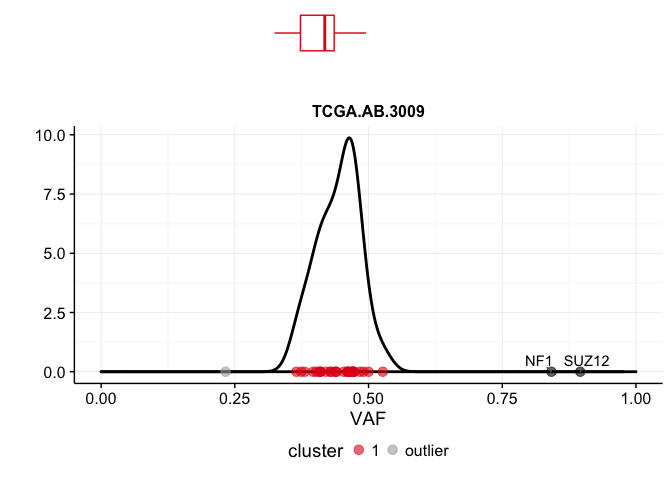

```r
#Visualizing results. Highlighting those variants on copynumber altered variants.
plotClusters(clusters = tcga.ab.3009.het, genes = 'CN_altered', showCNvars = TRUE)
```

Above figure shows two genes NF1 and SUZ12 with high VAF’s, which is due to copy number alteraions (deletion). Those two genes are ignored from analysis.

### 6.5.2 MATH (Mutant-Allele Tumor Heterogeneity) scores to infer extent of heterogeneity.

Although clustering of variant allele frequencies gives us a fair idea on heterogeneity, it is also possible to measure the extent of heterogeneity in terms of a numerical value. MATH score is a simple quantitative measure of intra-tumor heterogeneity, which calculates the width of the vaf distribution. Higher MATH scores are found to be associated with poor outcome. MATH score can also be used a proxy variable for survival analysis 7.

```r
#we will specify for random 4 patients.
laml.math = math.score(maf = laml, vafCol = 'i_TumorVAF_WU',
                       sampleName = c('TCGA.AB.3009', 'TCGA.AB.2849', 'TCGA.AB.3002', 'TCGA.AB.2972'))
```

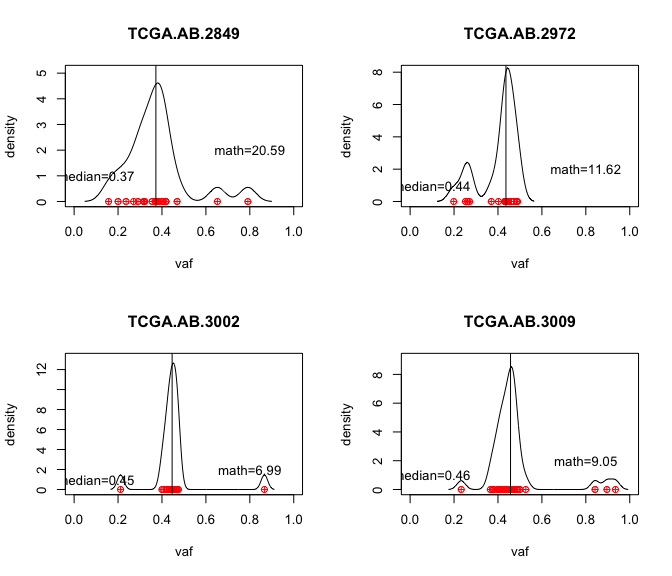

```r
print(laml.math)
```

```
##    Tumor_Sample_Barcode      MATH MedianAbsoluteDeviation Frame_Shift_Del
## 1:         TCGA.AB.2849 20.588348                5.170000               0
## 2:         TCGA.AB.2972 11.621572                3.420000               0
## 3:         TCGA.AB.3002  6.991207                2.104062               0
## 4:         TCGA.AB.3009  9.045040                2.789054               0
##    Frame_Shift_Ins In_Frame_Del In_Frame_Ins Missense_Mutation
## 1:               1            0            0                16
## 2:               1            0            0                16
## 3:               0            0            0                15
## 4:               5            0            1                25
##    Nonsense_Mutation Splice_Site total
## 1:                 1           2    20
## 2:                 2           1    20
## 3:                 1           5    21
## 4:                 2           1    34
```

From the above results, sample TCGA.AB.2849 has highest of MATH score (20.58) compared to rest of the three samples. It is also evident from the density plot, that vaf distribution is wider for this sample, whereas rest of three samples have sharp peaks with relatively low MATH scores, suggesting more homogeneity and lesser heterogeneity.

## 6.6 Mutational Signatures.

Every cancer, as it progresses leaves a signature characterised by specific pattern of nucleotide substitutions. [Alexandrov et.al](http://www.nature.com/nature/journal/v500/n7463/full/nature12477.html) have shown such mutational signatures, derived from over 7000 cancer samples. Such signatures can be extracted by decomposiong matrix of nucleotide substitutions, classified into 96 substitution classes based on immediate bases sorrouding the mutated base. Extracted signatures can also be compared to those [21 validated signatures](http://cancer.sanger.ac.uk/cosmic/signatures).

`extractSignatures` uses non-negative matrix factorization to decompose nx96 dimesion matrix into r signatures 8. By default function runs nmf on 6 ranks and chooses the best possible value based on maximum cophenetic-correlation coefficients. It is also possible to manually specify r. Once decomposed, signatures are compared against known 21 signatures derived from [Alexandrov et.al](http://www.nature.com/nature/journal/v500/n7463/full/nature12477.html), and correlation coeeficient is calculated to identify best match 9.

NOTE: Eventhough reading fasta and extracting bases is fairly fast, it is a memory consuming process as it occupies ~3gb of memory while running.

```r
#First we extract adjacent bases to the mutated locus and clssify them into 96 substitution classes.
laml.tnm = trinucleotideMatrix(maf = laml, ref_genome = '/path/to/hg19.fa',
                               prefix = 'chr', add = TRUE, ignoreChr = 'chr23', useSyn = TRUE)
```

```r
#Run main function with maximum 6 signatures.
laml.sign = extractSignatures(mat = laml.tnm, nTry = 6, plotBestFitRes = FALSE)
## Warning : Found zero mutations for conversions A[T>G]C
## Estimating best rank..
## Using 2 as a best-fit rank based on maximum cophenetic correlation coefficient.
## Comparing against experimentally validated 21 signatures.. (See Alexandrov et.al Nature 2013 for details.)
## Found Signature_1 most similar to validated Signature_1B. Correlation coeff: 0.788340817468816
## Found Signature_2 most similar to validated Signature_1A. Correlation coeff: 0.724579532825333
```

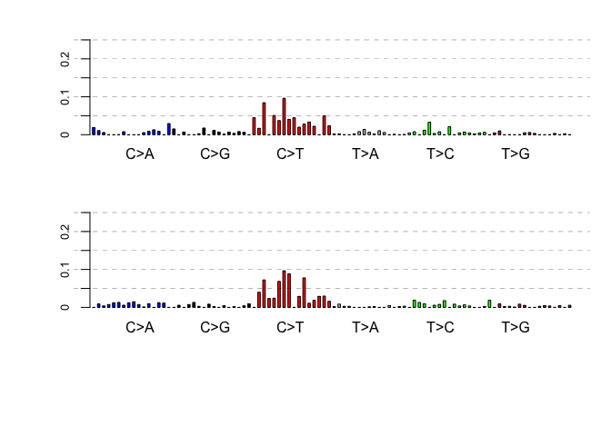

```r
plotSignatures(laml.sign)
```

`extractSignatures` gives a warning that no mutations are found for class A[T>G]C conversions. This is possible when the number of samples are low or in tumors with low mutation rate, such as in this case of Leukemia. In this scenario, a small positive value is added to avoid computational difficulties. It also prints other statistics for range of values that was tried, and chooses the rank with highest cophenetic metric (for above example r=2). Above stats should give an estimate of range of best possible r values and in case the chosen r is overestimating, it is also possible to be re-run `extractSignatures` by manually specifying r.

Once decomposed, signatures are compared against known and validated signatures from Sanger 9. In the above exaple, 2 signatures are derived. One of the signatures is most similar to validated signature_1A with a high correlation coefficient. Signature_1A is a result of elevated rate of spontaneous deamination of 5-methyl-cytosine, which results in C>T transitions and which predominantly occurs at NpCpG trinucleotide which is a most common process in AML 9,10.

# 7 Variant Annotations

## 7.1 Annotating variants using Oncotator.

We can also annotate variants using [oncotator](http://www.broadinstitute.org/oncotator/) API 11. `oncotate` function quires oncotator web api to annotate given set of variants and converts them into MAF format. Input should be a five column file with chr, start, end, ref_allele, alt_allele. However, it can conatain other information such as sample names (Tumor_Sample_Barcode), read counts, vaf information and so on, but only first five columns will be used, rest of the columns will be attached at the end of the table.

```r
var.file = system.file('extdata', 'variants.tsv', package = 'maftools')
#This is what input looks like
var = read.delim(var.file, sep = '\t')
head(var)
```

```
##   chromsome    start      end     ref alt Tumor_Sample_Barcode
## 1      chr4 55589774 55589774       A   G               fake_1
## 2      chr4 55599321 55599321       A   T               fake_2
## 3      chr4 55599332 55599332       G   T               fake_3
## 4      chr4 55599320 55599320       G   T               fake_4
## 5     chr15 41961117 41961123 TGGCTAA   -               fake_4
## 6      chr4 55599320 55599320       G   T               fake_5
```

```r
#Annotate
var.maf = oncotate(maflite = var.file, header = TRUE)
```

```r
#Results from oncotate. First 20 columns.
var.maf[1:10, 1:20, with = FALSE]
```

NOTE: This is quite time consuming if input is big.

## 7.2 Coverting annovar output to MAF.

Annovar is one of the most widely used Variant Annotation tool in Genomics 12. Annovar output is generally in a tabular format with various annotation columns. This function converts such annovar output files into MAF. This function requires that annovar was run with gene based annotation as a first operation, before including any filter or region based annotations.

e.g, `table_annovar.pl example/ex1.avinput humandb/ -buildver hg19 -out myanno -remove -protocol (refGene),cytoBand,dbnsfp30a -operation (g),r,f -nastring NA`

`annovarToMaf` mainly uses gene based annotations for processing, rest of the annotation columns from input file will be attached to the end of the resulting MAF.

As an example we will annotate the same file which was used above to run `oncotate` function. We will annotate it using annovar with the following command. For simplicity, here we are including only gene based annotations but one can include as many annotations as they wish. But make sure the fist operation is always gene based annotation.

```bash
$perl table_annovar.pl variants.tsv ~/path/to/humandb/ -buildver hg19
-out variants --otherinfo -remove -protocol ensGene -operation g -nastring NA
```

Output generated is stored as a part of this package. We can convert this annovar output into MAF using `annovarToMaf`.

```r
var.annovar = system.file("extdata", "variants.hg19_multianno.txt", package = "maftools")
var.annovar.maf = annovarToMaf(annovar = var.annovar, Center = 'CSI-NUS', refBuild = 'hg19',
                               tsbCol = 'Tumor_Sample_Barcode', table = 'ensGene', header = TRUE)
```

```
## Converting Ensemble Gene IDs into HGNC gene symbols.
```

```
## Done! Original ensemble gene IDs are preserved under field name ens_id
```

```
##     Hugo_Symbol Entrez_Gene_Id  Center NCBI_Build Chromosome
##  1:         KIT             NA CSI-NUS       hg19       chr4
##  2:         KIT             NA CSI-NUS       hg19       chr4
##  3:         KIT             NA CSI-NUS       hg19       chr4
##  4:         KIT             NA CSI-NUS       hg19       chr4
##  5:         KIT             NA CSI-NUS       hg19       chr4
##  6:         KIT             NA CSI-NUS       hg19       chr4
##  7:         KIT             NA CSI-NUS       hg19       chr4
##  8:         MGA             NA CSI-NUS       hg19      chr15
##  9:         MGA             NA CSI-NUS       hg19      chr15
## 10:         MGA             NA CSI-NUS       hg19      chr15
##     Start_Position End_Position Strand Variant_Classification Variant_Type
##  1:       55589774     55589774      +      Missense_Mutation          SNP
##  2:       55599321     55599321      +      Missense_Mutation          SNP
##  3:       55599332     55599332      +      Missense_Mutation          SNP
```

[output cut: 51 more lines]

Annovar, when used with Ensemble as a gene annotation source, uses ensemble gene IDs as Gene names. In that case, use `annovarToMaf` with argument `table` set to `ensGene` which converts ensemble gene IDs into HGNC symbols.

# 8 Other useful functions.

## 8.1 Subsetting MAF

We can also subset MAF using function `subsetMaf`

```r
##Extract data for samples 'TCGA.AB.3009' and 'TCGA.AB.2933'  (Printing just 5 rows for display convenience)
subsetMaf(maf = laml, tsb = c('TCGA.AB.3009', 'TCGA.AB.2933'))[1:5]
```

```
##    Hugo_Symbol Entrez_Gene_Id           Center NCBI_Build Chromosome
## 1:      ABCB11           8647 genome.wustl.edu         37          2
## 2:       ACSS3          79611 genome.wustl.edu         37         12
## 3:        ANK3            288 genome.wustl.edu         37         10
## 4:       AP1G2           8906 genome.wustl.edu         37         14
## 5:         ARC          23237 genome.wustl.edu         37          8
##    Start_Position End_Position Strand Variant_Classification Variant_Type
## 1:      169780250    169780250      +      Missense_Mutation          SNP
## 2:       81536902     81536902      +      Missense_Mutation          SNP
## 3:       61926581     61926581      +            Splice_Site          SNP
## 4:       24033309     24033309      +      Missense_Mutation          SNP
## 5:      143694874    143694874      +      Missense_Mutation          SNP
##    Reference_Allele Tumor_Seq_Allele1 Tumor_Seq_Allele2
## 1:                G                 G                 A
## 2:                C                 C                 T
## 3:                C                 C                 A
## 4:                C                 C                 T
## 5:                C                 C                 G
##    Tumor_Sample_Barcode Protein_Change    t_vaf i_transcript_name
## 1:         TCGA.AB.3009       p.A1283V 46.97218       NM_003742.2
## 2:         TCGA.AB.3009        p.A266V 47.32510       NM_024560.2
## 3:         TCGA.AB.3009                43.99478       NM_020987.2
## 4:         TCGA.AB.3009        p.R346Q 47.08000       NM_003917.2
## 5:         TCGA.AB.3009        p.W253C 42.96435       NM_015193.3
```

```r
##Same as above but return output as an MAF object
subsetMaf(maf = laml, tsb = c('TCGA.AB.3009', 'TCGA.AB.2933'), mafObj = TRUE)
```

```
## Creating oncomatrix (this might take a while)..
```

```
## Sorting..
```

```
## An object of class  MAF
##                    ID          summary Mean Median
##  1:        NCBI_Build               37   NA     NA
##  2:            Center genome.wustl.edu   NA     NA
##  3:           Samples                2   NA     NA
##  4:            nGenes               34   NA     NA
##  5:   Frame_Shift_Ins                5  2.5    2.5
##  6:      In_Frame_Ins                1  0.5    0.5
##  7: Missense_Mutation               26 13.0   13.0
##  8: Nonsense_Mutation                2  1.0    1.0
##  9:       Splice_Site                1  0.5    0.5
## 10:             total               35 17.5   17.5
```

Specifiying queries and controlling output fields.

```r
##Select all Splice_Site mutations from DNMT3A and NPM1
subsetMaf(maf = laml, genes = c('DNMT3A', 'NPM1'), query = "Variant_Classification == 'Splice_Site'")
```

```
##    Hugo_Symbol Entrez_Gene_Id           Center NCBI_Build Chromosome
## 1:      DNMT3A           1788 genome.wustl.edu         37          2
## 2:      DNMT3A           1788 genome.wustl.edu         37          2
## 3:      DNMT3A           1788 genome.wustl.edu         37          2
## 4:      DNMT3A           1788 genome.wustl.edu         37          2
## 5:      DNMT3A           1788 genome.wustl.edu         37          2
## 6:      DNMT3A           1788 genome.wustl.edu         37          2
##    Start_Position End_Position Strand Variant_Classification Variant_Type
## 1:       25459874     25459874      +            Splice_Site          SNP
## 2:       25467208     25467208      +            Splice_Site          SNP
## 3:       25467022     25467022      +            Splice_Site          SNP
## 4:       25459803     25459803      +            Splice_Site          SNP
## 5:       25464576     25464576      +            Splice_Site          SNP
## 6:       25469029     25469029      +            Splice_Site          SNP
##    Reference_Allele Tumor_Seq_Allele1 Tumor_Seq_Allele2
## 1:                C                 C                 G
## 2:                C                 C                 T
## 3:                A                 A                 G
## 4:                A                 A                 C
## 5:                C                 C                 A
## 6:                C                 C                 A
##    Tumor_Sample_Barcode Protein_Change t_vaf i_transcript_name
## 1:         TCGA.AB.2818        p.R803S 36.84       NM_022552.3
## 2:         TCGA.AB.2822                62.96       NM_022552.3
## 3:         TCGA.AB.2891                34.78       NM_022552.3
## 4:         TCGA.AB.2898                46.43       NM_022552.3
## 5:         TCGA.AB.2934        p.G646V 37.50       NM_022552.3
## 6:         TCGA.AB.2968        p.E477* 40.00       NM_022552.3
```

```r
##Select all variants with VAF above 30%
subsetMaf(maf = laml, query = "t_vaf > 30")
```

```
##       Hugo_Symbol Entrez_Gene_Id           Center NCBI_Build Chromosome
##    1:      ABCA10          10349 genome.wustl.edu         37         17
##    2:       ABCA4             24 genome.wustl.edu         37          1
##    3:      ABCB11           8647 genome.wustl.edu         37          2
##    4:       ABCC3           8714 genome.wustl.edu         37         17
##    5:       ABCF1             23 genome.wustl.edu         37          6
##   ---
## 1312:      ZNF687          57592 genome.wustl.edu         37          1
## 1313:      ZNF689         115509 genome.wustl.edu         37         16
## 1314:      ZNF75D           7626 genome.wustl.edu         37         23
## 1315:       ZNF99           7652 genome.wustl.edu         37         19
## 1316:        ZPBP          11055 genome.wustl.edu         37          7
##       Start_Position End_Position Strand Variant_Classification
##    1:       67170917     67170917      +            Splice_Site
##    2:       94490594     94490594      +      Missense_Mutation
```

[output cut: 33 more lines]

```r
##Same as above but include only 'Protein_Change' column in the output
subsetMaf(maf = laml, query = "t_vaf > 30", fields = 'Protein_Change')
```

```
##       Hugo_Symbol Chromosome Start_Position End_Position Reference_Allele
##    1:      ABCA10         17       67170917     67170917                T
##    2:       ABCA4          1       94490594     94490594                C
##    3:      ABCB11          2      169780250    169780250                G
##    4:       ABCC3         17       48760974     48760974                C
##    5:       ABCF1          6       30554429     30554429                G
##   ---
## 1312:      ZNF687          1      151259855    151259855                C
## 1313:      ZNF689         16       30616519     30616519                G
## 1314:      ZNF75D         23      134428053    134428053                T
## 1315:       ZNF99         19       22952090     22952090                C
## 1316:        ZPBP          7       50022985     50022985                C
##       Tumor_Seq_Allele1 Tumor_Seq_Allele2 Variant_Classification
##    1:                 T                 C            Splice_Site
##    2:                 C                 T      Missense_Mutation
```

[output cut: 21 more lines]

## 8.2 Plotting VAF

maftools has few other functions such as `plotVaf` and `genesToBarcodes` which helps to plot vaf distributions and maps samples where a given genes are mutated respectively.

# 9 References

1. Cancer Genome Atlas Research, N., Genomic and epigenomic landscapes of adult de novo acute myeloid leukemia. N Engl J Med, 2013. 368(22): p. 2059-74.
2. Leiserson, M.D., et al., CoMEt: a statistical approach to identify combinations of mutually exclusive alterations in cancer. Genome Biol, 2015. 16: p. 160.
3. Tamborero, D., A. Gonzalez-Perez, and N. Lopez-Bigas, OncodriveCLUST: exploiting the positional clustering of somatic mutations to identify cancer genes. Bioinformatics, 2013. 29(18): p. 2238-44.
4. Dees, N.D., et al., MuSiC: identifying mutational significance in cancer genomes. Genome Res, 2012. 22(8): p. 1589-98.
5. Madan, V., et al., Comprehensive mutational analysis of primary and relapse acute promyelocytic leukemia. Leukemia, 2016. doi: 10.1038/leu.2016.69.
6. Olshen AB, Venkatraman ES, Lucito R, Wigler M. Circular binary segmentation for the analysis of array-based DNA copy number data. Biostatistics. 2004;5(4):557–72. doi: 10.1093/biostatistics/kxh008.
7. Mroz, E.A., et al., Intra-tumor genetic heterogeneity and mortality in head and neck cancer: analysis of data from the Cancer Genome Atlas. PLoS Med, 2015. 12(2): p. e1001786.
8. Gaujoux, R. and C. Seoighe, A flexible R package for nonnegative matrix factorization. BMC Bioinformatics, 2010. 11: p. 367.
9. Alexandrov, L.B., et al., Signatures of mutational processes in human cancer. Nature, 2013. 500(7463): p. 415-21.
10. Welch, J.S., et al., The origin and evolution of mutations in acute myeloid leukemia. Cell, 2012. 150(2): p. 264-78.
11. Ramos, A.H., et al., Oncotator: cancer variant annotation tool. Hum Mutat, 2015. 36(4): p. E2423-9.
12. Wang, K., Li, M. & Hakonarson, H. ANNOVAR: functional annotation of genetic variants from high-throughput sequencing data. Nucleic Acids Res 38, e164 (2010).